# Hypothesis Testing Errors

C’mon… what could go wrong? Part Deux!

P. Lombardo

## Loading packages, etc.

```r
library(tidyverse)
library(patchwork)
library(DescTools)
library(broom)
source("source_files/HT_errors_ANOVA.R")
```

## Exploring Type II Error rates

A *Type II Error* occurs when we the results of our hypothesis test **incorrectly tell us to fail to reject $H_0$**.

- Type II Errors only occur when the null hypothesis is false
- In these cases, we will have our $P$-value > $\alpha$; since $H_0$ is false, this has us make the *wrong conclusion* of failing to reject $H_0$.
- Summary: the null hypothesis is *actually* false, but because of other factors our sample gave us no reason to reject it. (We will explore such factors below.)

**EVERY HYPOTHESIS TEST IS IN DANGER OF MAKING THIS MISTAKE**

Naturally, however, we want to minimize the *likelihood* of this occurring. Let’s use our functions from before to explore type II error rates.

To better explore type II error rates, we lean on the `pvalue_sim()` function, which collects 2,000 $P$-values from hypothesis tests drawing from a population with a population mean of 100.

- *Since our function is set up to sample from a population with a mean of 100,* to make the null hypothesis *false* we could set `null_mu = 90`. (This is not the only `null_mu` that makes the null hypothesis false, but it’s a nice one to start with.)

Let’s assume we use a sample size of `n=30` and the population standard deviation is `sigma= 20`. Use `pvalue_sim()` to generate some simulated $P$-values:

```r
pvals<-pvalue_sim(null_mu =90,
                  # Note the null_mu = 90 makes the
                  # null hypothesis false!
                  n = 30,
                  sigma = 20)
```

**How many of these simulated $P$-values would lead us to *fail to reject* our null hypothesis?** Assume $\alpha = 0.05$.

```r
#Place code here.
sum(pvals >= 0.05)/length(pvals)
```

```
## [1] 0.2485
```

Let’s visualize our $P$-values:

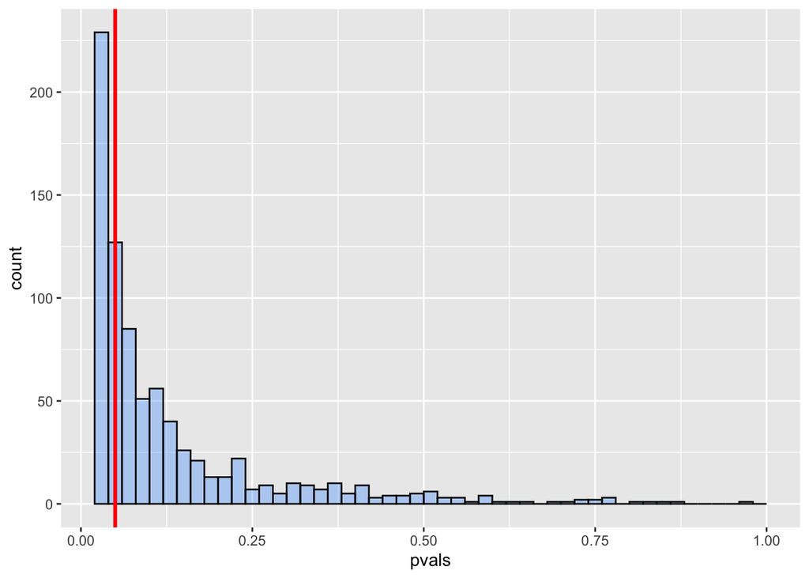

```r
hist_with_alpha(pvals,0.05,breaks = 1:50/50)
```

1. **What do you notice about the *shape* of the histogram for $P$-values when the null hypothesis is *false*?**

This has a positive skew to it, meaning that *small* $P$-values occur more often than larger ones.

2. How does this *shape* of the histogram for $P$-values differ from the case where the null hypothesis was true?

In the case where the null hypothesis is true, the shape was uniform. Each possible value for a $P$-value was equally likely.

#### Time permitting: what affects the Type II error Rate?

Remember that our simulations sample from a population *where the true population mean is 100*. So to work with Type II Errors, we need to make sure we choose `null_mu` values away from 100. Note that the code below provides the percentage of tests that *incorrectly tell us to “fail to reject” the null hypothesis!*

- $n$, our sample size
- $\sigma$, how much variation in the population there is,
- $alpha$, the significance level of the test.

```r
beta<-typeII_rate(null_mu = 93,
            n = 30,
            sigma = 30,
            alpha = 0.05)

# Power is  (1 - Type II Error Rate)  or 1 - \beta
1 - beta
```

```
## [1] 0.206
```

```r
beta
```

```
## [1] 0.794
```

Recommendation: For each of the arguments above, describe how increasing them affects both Power and the Type II error rate.

You can use this [$P$-value distribution](https://stem.endicott.edu/pl-shiny/power/p-vals-distribution/) interactive visualization to explore these ideas as well. The simulator draws samples from a population with a mean of 100 (as our example above), so leaving setting the null hypothesis to values *NOT EQUAL* to 100 will let you explore **Type II errors.**